# Producing Graphics For Portland Sediment Toxicity Data

# Strategy

Overall, we want a visually simple graphic that captures the most important aspects of contamination in Portland harbor. From other analyses, we know that 1. Metals levels are consistently below screening levels 2. Most pesticide residues were never or almost never detected, the only exceptions being the DDT residues. 3. Other contaminants exceed screening levels at about half of sampling locations. 4. Levels of contaminants are highly correlated

Multiple contaminants with complicated names can make for intimidating graphic. We need to identify ways to simplify the data display without distorting the meaning. Screening levels are available for Total PAHs, Total PCBs, and sum of DDT residues, suggesting we can focus on those three aggregate indicators of contamination and simplify data presentation. There is no equivalent way of simplifying display of the metals data, but all metals are below levels of concern.

The data is complicated by the presence of many non-detects. Her we develop estimates of “real” values in three ways: 1. Treating each non-detect as having been observed at the reporting limit (which clearly overstates actual levels, and confounds observation with analytic concerns). 2. Treating each non-detect as half the observed level. While this is logically better than assuming that each non-detect was present at the detection limit, it has no basis in statistical theory, and is essentially arbitrary 3. Using lognormal maximum likelihood estimation to estimate conditional expected value of observations, given only that they fell below a detection limit.

Here we consider both and ‘J’ flags to be "non-detects’ as both are below the reporting limits. A more sophisticated analysis, with more data might model ‘J’ and ‘U’ flags differently, but here we combine them.

Details on the methods are described in the R Notebook “Conditional Means of Censored Distributions”

## Special Considerations

1. Reporting limits for organic contaminants from sample CSP-8 were exceptionally high. For PCBs the reporting limit was sufficiently high to bias any approach to estimating PCB loads, so we delete this point from consideration
2. DDT concentrations from Sample CSS-15 were replicates that failed a QA/QC check. One was a non-detect, while the other was roughly double the reporting limit. Here we report results based on averaging imputed values of the non-detect with the observed value from the other sample.

# Metals Data

No reorganization needed. All metals are below levels of concern, and there are no suitable aggregate screening levels for metals or sum of metals. So there is little point in reporting specific values, and no easy way to summarize results. We could show one or two metals of interest – like Mercury – or just report that all are below levels of concern.

# PAH Data

```r
pah_res<- sed_data_long %>%
  filter (cgroup =='PAHs') %>%

  mutate(censored = censored>0) %>%

  group_by(Contaminant) %>%
  mutate(LikCensored = LNConditionalMeans(CONCENTRATION, censored)) %>%
  ungroup()  %>%
  mutate(HalfDL = ifelse(censored, CONCENTRATION/2, CONCENTRATION)) %>%
  group_by(SAMPLE_ID) %>%
  summarize(LNtotPAH = sum(LikCensored),
            halfDLtotPAH = sum(HalfDL),
            totPAH = sum(CONCENTRATION))
```

# PCB Data

```r
pcb_res<- sed_data_long %>%
  filter (cgroup =='PCBs') %>%

  # CSP-8 had exceptionally high PCB detection limits
  filter(SAMPLE_ID != 'CSP-8') %>%

  mutate(censored = censored>0) %>%
  group_by(Contaminant) %>%
  mutate(LikCensored = LNConditionalMeans(CONCENTRATION, censored)) %>%
  ungroup()  %>%
  group_by(SAMPLE_ID) %>%
  summarize(LNtotPCB = sum(LikCensored),
            totPCB = sum(CONCENTRATION))
```

# Pesticides Data

To be accurate, we need to calculate estimates of the censored values (ND, Half ND and Maximum Likelihood) on the original raw data and average the results, rather than calculate estimates based on an average of an observation and a reporting limit.

```r
tmp <- the.data %>%
  filter(PARAMETER_NAME=="4,4'-DDT") %>%
  filter(SAMPLE_ID == 'CSS-15') %>%
  filter(is.na(`%_RECOVERY`)) %>%
  filter(SAMPLE_ID != 'QC') %>%
  mutate(censored = LAB_QUALIFIER %in% c('U', 'J')) %>%
  mutate(CONCENTRATION = ifelse(censored, REPORTING_LIMIT, CONCENTRATION)) %>%
  select(censored, CONCENTRATION, REPORTING_LIMIT) %>%
  mutate(halfdl = ifelse(censored, REPORTING_LIMIT/2, CONCENTRATION))
(hdl <- mean(tmp%>%pull(halfdl)))
```

```
[1] 0.4675
```

### Calculate Average by Maximum Likelihood Estimator

```r
est <- the.data %>%
  filter(PARAMETER_NAME=="4,4'-DDT") %>%
  filter(is.na(`%_RECOVERY`)) %>%
  filter(SAMPLE_ID != 'QC') %>%
  select(SAMPLE_ID, CONCENTRATION, REPORTING_LIMIT, LAB_QUALIFIER) %>%
  mutate(censored = LAB_QUALIFIER %in% c('U', 'J')) %>%
  mutate(CONCENTRATION = ifelse(censored, REPORTING_LIMIT, CONCENTRATION)) %>%
  mutate(lnest = LNConditionalMeans(CONCENTRATION, censored)) %>%
  filter(SAMPLE_ID == 'CSS-15') %>%
  pull(lnest)
(mle <- mean(est))
```

```
[1] 0.4457593
```

```r
rm(tmp, est)
```

## Assemble Pesticides Data

```r
pests_data_long <- sed_data_long %>%
  filter (cgroup =='Pesticides') %>%
  mutate(censored = censored>0) %>%
  group_by(Contaminant) %>%
  mutate(LikCensored = LNConditionalMeans(CONCENTRATION, censored)) %>%
  ungroup()  %>%
  mutate(HalfDL = ifelse(censored, CONCENTRATION/2, CONCENTRATION))
```

###Correct DDT Value.

```r
pests_data_long <- pests_data_long %>%
  mutate(LikCensored = ifelse(SAMPLE_ID =='CSS-15' & Contaminant =="4,4'-DDT",
                              mle, LikCensored)) %>%
  mutate(HalfDL = ifelse(SAMPLE_ID=='CSS-15' & Contaminant == "4,4'-DDT",
                         hdl, HalfDL))
rm(mle, hdl)
```

### Assemble Final DDT Residue Data

```r
pesticide_res <- pests_data_long %>%
  group_by(SAMPLE_ID) %>%
  summarize(LNtotDDT = sum(LikCensored),
            halfDLtotDDT = sum(HalfDL),
            totDDT = sum(CONCENTRATION))
```

#Assemble Final Results

```r
res_wide <- site.info %>%
  left_join(pah_res) %>%
  left_join(pcb_res) %>%
  left_join(pesticide_res)
```

```r
tmp <- res_wide %>% select(starts_with('LN'))

cor(log(tmp), use='pairwise')
```

```
          LNtotPAH  LNtotPCB  LNtotDDT
LNtotPAH 1.0000000 0.6416874 0.5920834
LNtotPCB 0.6416874 1.0000000 0.9182420
LNtotDDT 0.5920834 0.9182420 1.0000000
```

```r
res_long_MLE <- res_wide %>%
  select(SAMPLE_ID, sitename, starts_with('LNtot')) %>%
  rename_at(3:5, ~substr(.,nchar(.)-2, nchar(.))) %>%
  gather(key = 'Contaminant', value = 'MLE', -SAMPLE_ID, -sitename)

res_long_RL <- res_wide %>%
  select(SAMPLE_ID, sitename, starts_with('tot')) %>%
  rename_at(3:5, ~substr(.,nchar(.)-2, nchar(.))) %>%
  gather(key = 'Contaminant', value = 'RL', -SAMPLE_ID, -sitename)

res_long_HRL <- res_wide %>%
  select(SAMPLE_ID, sitename, starts_with('half')) %>%
  rename_at(3:5, ~substr(.,nchar(.)-2, nchar(.))) %>%
  gather(key = 'Contaminant', value = 'HRL', -SAMPLE_ID, -sitename)

res <- res_long_MLE %>% left_join(res_long_HRL) %>% left_join(res_long_RL) %>%
  mutate(Contaminant = factor(Contaminant, levels = c('DDT', 'PAH', 'PCB'),
                              labels = c('DDT Residues', 'Total PAHs', 'Total PCBs')))
rm(res_long_MLE, res_long_HRL, res_long_RL)
```

# Cleanup

```r
rm(parmnames, sed_names, metal_names, pah_names, pah_res, pcb_names, pcb_res,
   pesticide_names, pesticide_res, pests_data_long)
rm(the.data, sed_data_long, site.info)
```

# Screening Levels

```r
pcb <- c(22.7, 180)
pah <- c(4022, 44792)
ddt <- c(1.58, 46.1)

sl <- tibble(Contaminant = rep(c('DDT Residues',
                                 'Total PAHs', 'Total PCBs'), each = 2),
             Threshold = rep(c('ERL','ERM'),3),
             Value = c(ddt,pah, pcb))
```

# Graphic2

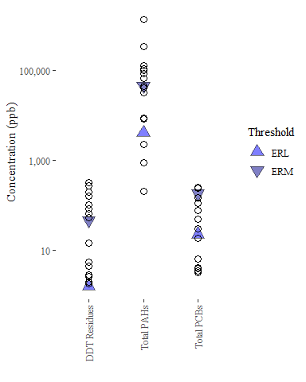

```r
plt <- ggplot(res, aes(Contaminant, MLE)) +
  #geom_boxplot() +
  geom_point(data = sl, aes(Contaminant, Value,
                                fill = Threshold, shape = Threshold),
                 size = 4, alpha = .5) +
  geom_point(shape = 1, size = 3) +
  scale_y_log10(labels=scales::comma) +

  scale_shape_manual(values = c(24,25)) +
  scale_fill_manual(values = c('blue1', 'blue4')) +
  ylab('Concentration (ppb)') +
  xlab ('') +
  theme_tufte() +
  #theme_minimal() +
  theme(axis.text.x = element_text(angle = 90, vjust=0.5, hjust=1))
plt
```

SO, what that shows is that despite DDT being outlawed for a generation, concentrations of DDT residues in Portland Harbor are well above levels of concern. Simimlarly, PAHs are usually above conservative screaning levels, and many sites had levels of PCBs avove levels of concern.

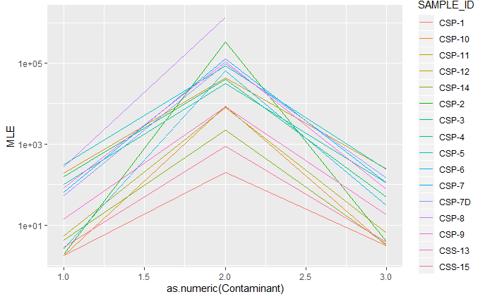

```r
ggplot(res, aes(as.numeric(Contaminant), MLE)) +
  geom_line(aes(color = SAMPLE_ID)) +
  scale_y_log10()
```